# Quantifies self-movement: An statistical study

Juan Luis Jurado

2023-11-26

```r
library(ggplot2)
library(plyr)
```

## Loading and preprocessing data

We will first load the data into R with the read.csv() function. Additionally, transforming the *date* column into “Date” class will help us during the analysis.

```r
activity = read.csv("activity.csv")
activity$date = as.Date(activity$date)
```

## What is mean total number of steps taken per day?

First, we compute the total number of steps per day, the mean and the median value (ignoring missing numbers). We do this using the date column as a factor.

```r
dailySteps = tapply(activity$steps, factor(activity$date), sum, na.rm = TRUE)
avg = mean(dailySteps, na.rm = TRUE)
mdn = median(dailySteps, na.rm = TRUE)
```

We obtain that the mean value for the number of steps taken in one day is approximately 9354, while the median is 10395. Then, we can plot the histogram of the total number of steps, showing where the mean and median lie.

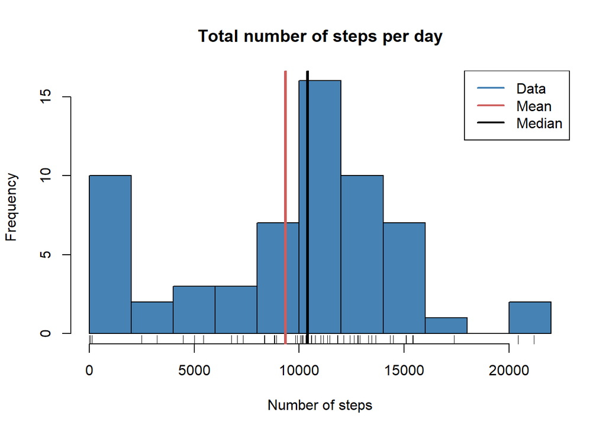

```r
hist(dailySteps, breaks = 10, main = "Total number of steps per day", xlab = "Number of steps", col = "steelblue")
rug(dailySteps)

abline(v = avg, col = "indianred", lw = 3)
abline(v = mdn, col = "black", lw = 3)

legend("topright", legend = c("Data", "Mean", "Median"),
       lty = c(1, 1, 1), lwd = c(2, 2, 2),
       col = c("steelblue", "indianred", "black"))
```

## What is the average daily activity pattern?

For this question, we first need to obtain the average number of steps taken for each of the different intervals across all days. Then, we just need to plot the interval of the day and the average number of steps taken.

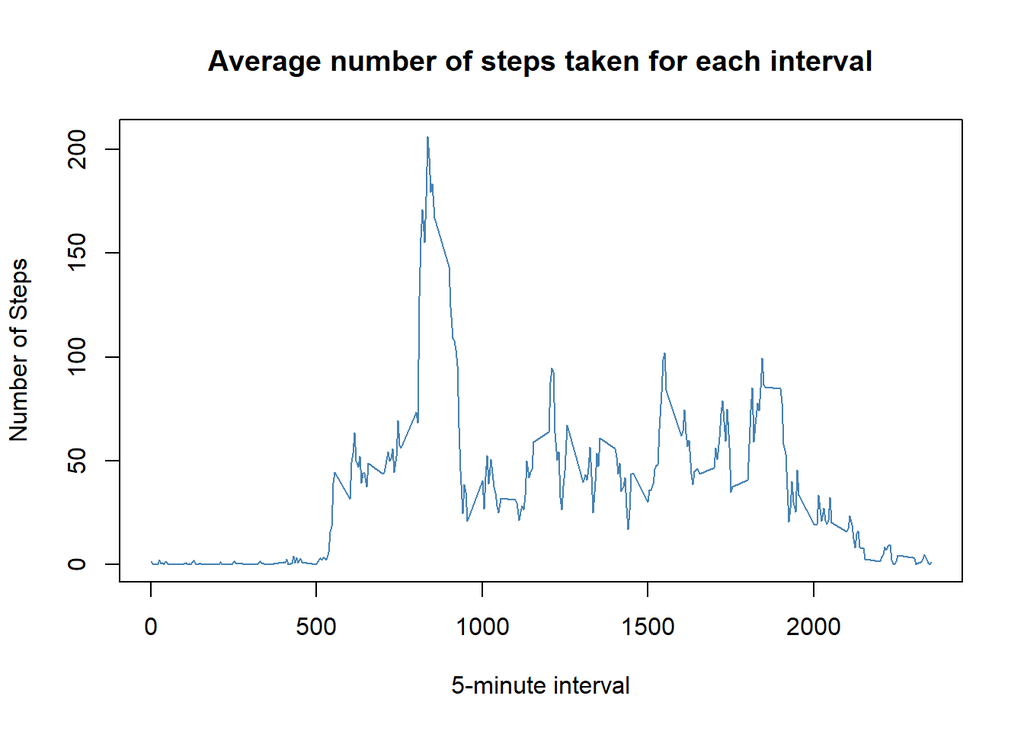

```r
stepsInterval = aggregate(steps ~ interval, activity, mean, na.rm = TRUE)

plot(stepsInterval$interval, stepsInterval$steps, type="l",
     main="Average number of steps taken for each interval",
     ylab="Number of Steps", xlab="5-minute interval", col="steelblue")
```

We now are asked to find the interval containing the highest number of steps (on average).

```r
maxInt = which.max(stepsInterval$steps)
```

Thus, the interval with the highest number of steps on average is interval 835, with 206 steps.

## Imputing missing values

Up until now, we have ignored the missing values on the dataset. However, we now need to impute this values to create a full tidy dataset. To do this, we will make use of the fact that we have already computed the mean value for each 5-minute interval of the day. Therefore, we will substitute each missing value with the average for its corresponding interval.

```r
nMV = sum(is.na(activity$steps))

N = length(activity$steps)
n = length(stepsInterval$steps)
for (i in seq_len(N)){
        if (is.na(activity$steps[i])){
                activity$steps[i] = stepsInterval$steps[i%%n + 1]
        }
}

nMV2 = sum(is.na(activity$steps))
```

We have first checked the number of missing values on the data, which returns 2304. We then used a loop to iterate and replace every missing value according to the devised strategy, and finally check that after the imputation the total number of MV is 0. Thus, the MV have been correctly imputed.

Now that the data set is complete, we will redo the analysis performed in the first section, to see how MV affected this result.

```r
dailySteps2 = tapply(activity$steps, factor(activity$date), sum)
avg2 = mean(dailySteps2)
mdn2 = median(dailySteps2)
```

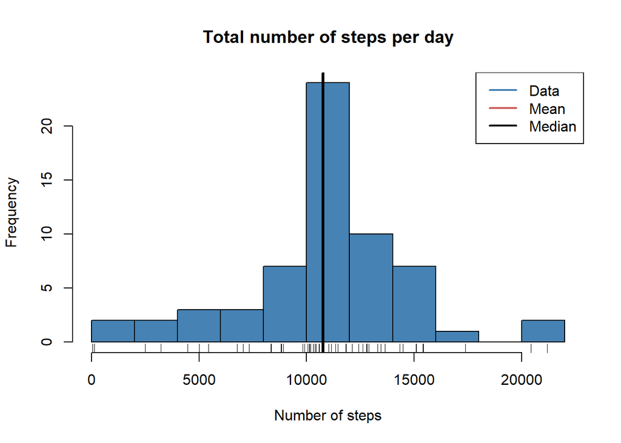

```r
hist(dailySteps2, breaks = 10, main = "Total number of steps per day", xlab = "Number of steps", col = "steelblue")
rug(dailySteps2)

abline(v = avg2, col = "indianred", lw = 3)
abline(v = mdn2, col = "black", lw = 3)

legend("topright", legend = c("Data", "Mean", "Median"),
       lty = c(1, 1, 1), lwd = c(2, 2, 2),
       col = c("steelblue", "indianred", "black"))
```

## Are there differences in activity patterns between weekdays and weekends?

First, we have written a function which takes a date as an input and outputs either “weekend” or “weekday” depending on the day of the week of the given date.

```r
day_class = function(date){

        if (weekdays(date) %in% c("Saturday","Sunday")){
                return("weekend")
        }
        else {
                return("weekday")
        }
}
```

Note that this function only works for certain languages in R. Thus, in order to guarantee the integrity of the results we must set the language to English.

```r
Sys.setlocale("LC_TIME", "English_United States.1252")
```

```
## [1] "English_United States.1252"
```

Now we can add a factor column to our dataset which classifies the different dates into weekdays or weekends.

```r
day = lapply(activity$date, FUN = day_class)
activity$day = factor(unlist(day))
```

Finally, we need to repeat the time series plot we made previously but using the complete dataset and making a distinction between weekdays and weekends. To do this, we subset our data into two different dataframes.

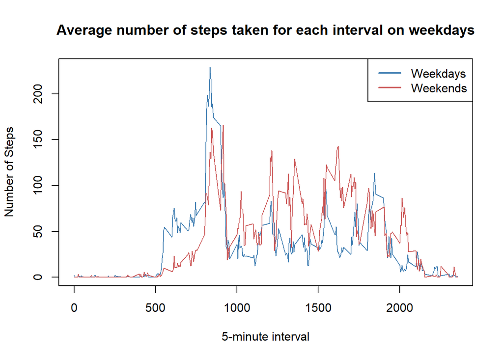

```r
activityWD = subset(activity, day == "weekday")
activityWE = subset(activity, day == "weekend")

stepsIntervalWD = aggregate(steps ~ interval, activityWD, mean)
stepsIntervalWE = aggregate(steps ~ interval, activityWE, mean)

plot(stepsIntervalWD$interval, stepsIntervalWD$steps, type="l",
     main="Average number of steps taken for each interval on weekdays",
     ylab="Number of Steps", xlab="5-minute interval", col="steelblue")
lines(stepsIntervalWE$interval, stepsIntervalWE$steps, type="l",
     main="Average number of steps taken for each interval on weekends",
     ylab="Number of Steps", xlab="5-minute interval", col="indianred")
legend("topright", legend = c("Weekdays", "Weekends"),
       lty = c(1, 1), lwd = c(2, 2),
       col = c("steelblue", "indianred"))
```